# World Mountains

Devi Sangeetha

1 July 2017

## R Markdown

Loading the libraries

Read the data from the input file

View the data

```
##   Rank                                 Mountain Height..m. Height..ft.
## 1    1 Mount Everest / Sagarmatha / Chomolungma       8848       29029
## 2    2               K2 / Qogir / Godwin Austen       8611       28251
## 3    3                            Kangchenjunga       8586       28169
## 4    4                                   Lhotse       8516       27940
## 5    5                                   Makalu       8485       27838
## 6    6                                  Cho Oyu       8188       26864
##   Prominence..m.                  Range
## 1           8848    Mahalangur Himalaya
## 2           4017      Baltoro Karakoram
## 3           3922 Kangchenjunga Himalaya
## 4            610    Mahalangur Himalaya
## 5           2386    Mahalangur Himalaya
## 6           2340    Mahalangur Himalaya
##                           Coordinates Parent.mountain First.ascent
## 1 27Â°59â²17â³N 86Â°55â²31â³Eï»¿                          1953
## 2 35Â°52â²53â³N 76Â°30â²48â³Eï»¿    Mount Everest         1954
## 3 27Â°42â²12â³N 88Â°08â²51â³Eï»¿    Mount Everest         1955
## 4 27Â°57â²42â³N 86Â°55â²59â³Eï»¿    Mount Everest         1956
## 5 27Â°53â²23â³N 87Â°05â²20â³Eï»¿    Mount Everest         1955
## 6 28Â°05â²39â³N 86Â°39â²39â³Eï»¿    Mount Everest         1954
##   Ascents.bef..2004 Failed.attempts.bef..2004
## 1            >>145                        121
## 2                45                        44
## 3                38                        24
## 4                26                        26
## 5                45                        52
## 6                79                        28
```

The columns exists in the dataset are:

1)Rank: Position in the rank of highest mountains in the world. (Integer) 2)Mountain: Name or names of the mountain. (Text separated by slashes) 3)Height (m): Height in meters of the mountain. (Integer) 4)Height (ft): Height in feet of the mountain. (Integer) 5)Prominence (m): (Topographic prominence)[https://en.wikipedia.org/wiki/Topographic_prominence] of the mountain in meters. (Integer) 6)Range: What mountain range does this mountain belong to. (Text) 7)Coordinates: Coordenates of the highest point. (Text in (WGS84)[https://en.wikipedia.org/wiki/World_Geodetic_System] format) 8)Parent mountain: (Line parent)[https://en.wikipedia.org/wiki/Line_parent] of the mountain. (Text) 9)First ascent: Year of first ascent. (Year-formatted Integer) 10)Ascents bef. 2004: Number of successful ascents before 2004. (Integer) 11)Failed attempts bef. 2004: Number of unsuccessful ascents before 2004. (Integer)

structure of dataset

```
## 'data.frame':    118 obs. of  11 variables:
##  $ Rank                     : int  1 2 3 4 5 6 7 8 9 10 ...
##  $ Mountain                 : Factor w/ 118 levels "Abi Gamin","Annapurna Dakshin",..: 76 47 50 65 67 14 19 72 82 3 ...
##  $ Height..m.               : int  8848 8611 8586 8516 8485 8188 8167 8163 8126 8091 ...
##  $ Height..ft.              : int  29029 28251 28169 27940 27838 26864 26795 26781 26660 26545 ...
##  $ Prominence..m.           : int  8848 4017 3922 610 2386 2340 3357 3092 4608 2984 ...
##  $ Range                    : Factor w/ 35 levels "Annapurna Himalaya",..: 20 4 14 20 20 20 7 21 26 1 ...
##  $ Coordinates              : Factor w/ 118 levels "27Â°38â²02â³N 88Â°07â²00â³Eï»¿ ",..: 13 88 3 11 9 18 42 37 64 40 ...
##  $ Parent.mountain          : Factor w/ 53 levels "","Annapurna",..: 1 34 34 34 34 34 20 6 9 6 ...
##  $ First.ascent             : Factor w/ 51 levels "1930","1931",..: 13 14 15 16 15 14 20 16 13 11 ...
##  $ Ascents.bef..2004        : Factor w/ 33 levels "",">>145 ","0",..: 2 22 18 13 22 30 25 23 26 17 ...
##  $ Failed.attempts.bef..2004: int  121 44 24 26 52 28 39 45 67 47 ...
```

Since the variable names are having “..”, rename them.

```r
names<-c("rank","mountain","height_m","height_ft","prominence_m","range","coordinates","parent_mountain","first_ascent","ascent_bef_2004","failed_bef_2004")
colnames(mount)<-names
summary(mount)
```

```
##       rank                     mountain      height_m      height_ft
##  Min.   :  1.00   Abi Gamin        :  1   Min.   :7200   Min.   :23622
##  1st Qu.: 30.25   Annapurna Dakshin:  1   1st Qu.:7316   1st Qu.:24004
##  Median : 59.50   Annapurna I      :  1   Median :7472   Median :24517
##  Mean   : 59.50   Annapurna II     :  1   Mean   :7578   Mean   :24862
##  3rd Qu.: 88.75   Annapurna III    :  1   3rd Qu.:7776   3rd Qu.:25510
##  Max.   :118.00   Apsarasas Kangri :  1   Max.   :8848   Max.   :29029
##                   (Other)          :112
##   prominence_m                       range
##  Min.   : 217.0   Mahalangur Himalaya   :12
##  1st Qu.: 712.8   Baltoro Karakoram     :10
##  Median :1332.5   Hispar Karakoram      :10
##  Mean   :1671.6   Dhaulagiri Himalaya   : 7
##  3rd Qu.:2297.2   Garhwal Himalaya      : 6
##  Max.   :8848.0   Kangchenjunga Himalaya: 6
##                   (Other)               :67
##                               coordinates       parent_mountain
##  27Â°38â²02â³N 88Â°07â²00â³Eï»¿ :  1   Mount Everest: 9
##  27Â°40â²56â³N 88Â°02â²40â³Eï»¿ :  1   Gasherbrum I : 8
##  27Â°42â²12â³N 88Â°08â²51â³Eï»¿ :  1   Cho Oyu      : 7
##  27Â°44â²27â³N 88Â°09â²31â³Eï»¿ :  1   Kangchenjunga: 7
##  27Â°46â²30â³N 86Â°58â²47â³Eï»¿ :  1   Distaghil Sar: 5
##  27Â°47â²16â³N 88Â°11â²43â³Eï»¿ :  1   K2           : 5
##  (Other)                            :112   (Other)      :77
##   first_ascent ascent_bef_2004 failed_bef_2004
##  1960   : 7    1      :25      Min.   :  0.0
##  1956   : 6    2      :21      1st Qu.:  1.0
##  1976   : 6    4      :14      Median :  3.0
##  1975   : 5    3      : 8      Mean   :  8.4
##  1954   : 4    6      : 6      3rd Qu.: 11.0
##  1958   : 4    0      : 5      Max.   :121.0
##  (Other):86    (Other):39      NA's   :3
```

### Distribution of Mountain Heights

# Prominence - The technical definition of “Mountain Prominence” is the vertical distance between a peak and the lowest contour line surrounding that peak and no higher peak.

With the prominence ,mountains are classified as seperate or it exists under any other parent

Lets us work more on this 1)Distribution of Prominence

```r
mount %>% ggvis(~prominence_m,fill :="darkviolet") %>% layer_densities() %>% add_axis("y",title_offset = 60)
```

2) Mountains which are Not-Prominent

```r
pmount<-mount %>% select(mountain,height_m,prominence_m,parent_mountain)%>%mutate(diff= height_m-prominence_m,prominent=ifelse(diff==0,"No","Yes"))

pmount%>% filter(prominent=="No")
```

```
##                                   mountain height_m prominence_m
## 1 Mount Everest / Sagarmatha / Chomolungma     8848         8848
##   parent_mountain diff prominent
## 1                    0        No
```

Since Mount Everest is the highest mountain in the world, it doesn’t have parent, so prominence is same as the height

3)Find the mountains wich have difference between height and prominence <5000

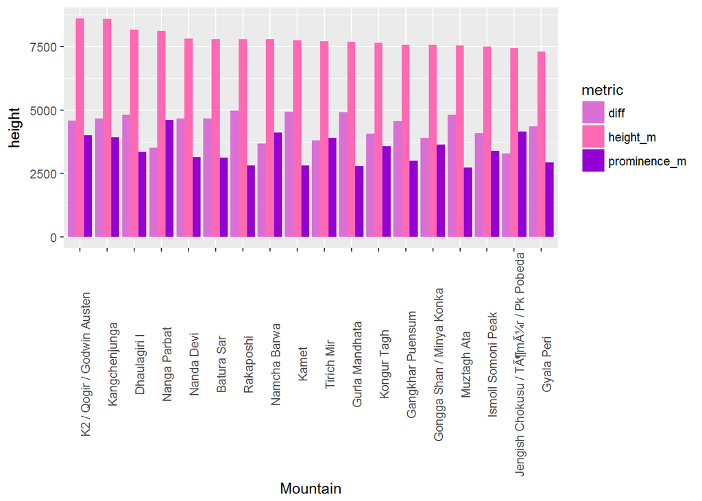

```r
dif<-pmount %>% filter(diff<=5000 & prominent=="Yes")%>% select(mountain,height_m,prominence_m,diff)
library(tidyr)



#dif %>%gather(metric,height,height_m:diff)%>%ggvis(x=~factor(mountain,levels=mountain),y=~height,fill=~factor(metric))%>%group_by(metric)%>%layer_bars(stack=TRUE) %>% add_axis("x",properties=axis_props(labels=list(angle=90,align="left")),title="Mountain",title_offset=200)%>%   add_axis("y",title="Height in Mtrs",title_offset=50)
#%>% add_legend("fill",title="Mountain Heights")%>%scale_nominal("fill", range = c("orchid", "hotpink","darkviolet"))

dif %>%gather(metric,height,height_m:diff)%>%ggplot(aes(x=factor(mountain,levels=mountain),y=height,fill=metric))+geom_bar(stat="identity",position="Dodge")+theme(axis.text.x = element_text(angle=90))+scale_fill_manual(values=c("orchid", "hotpink","darkviolet"))+labs(x="Mountain")
```

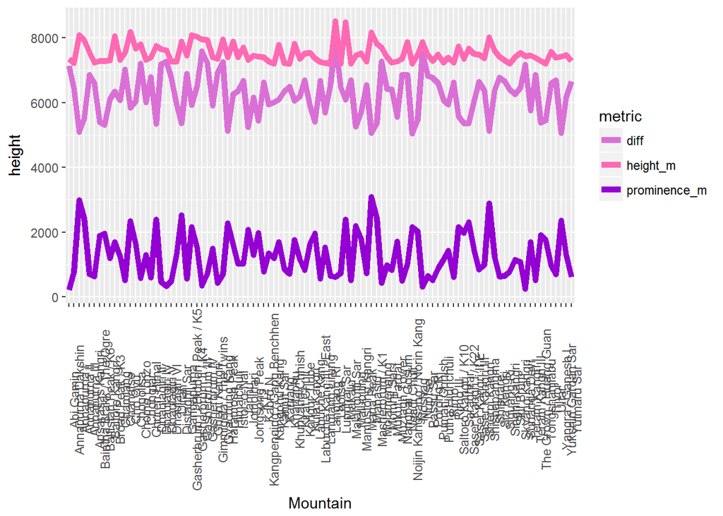

```r
pmount %>% filter(diff>5000 & prominent=="Yes")%>% select(mountain,height_m,prominence_m,diff)%>%gather(metric,height,height_m:diff)%>%ggplot(aes(x=factor(mountain),y=height,group=metric,color=metric))+geom_line(size=2)+theme(axis.text.x = element_text(angle=90))+scale_color_manual(values=c("orchid", "hotpink","darkviolet"))+labs(x="Mountain")
```

## World’s Highest Mountains

Find out the World’s top 10 highest mountains based on the heights in Mts.

```r
topm<-mount%>%select(mountain,height_m,rank)%>%filter(rank<=10)%>% arrange(desc(rank))

head(topm,10)
```

```
##                                    mountain height_m rank
## 1                               Annapurna I     8091   10
## 2                              Nanga Parbat     8126    9
## 3                                   Manaslu     8163    8
## 4                              Dhaulagiri I     8167    7
## 5                                   Cho Oyu     8188    6
## 6                                    Makalu     8485    5
## 7                                    Lhotse     8516    4
## 8                             Kangchenjunga     8586    3
## 9                K2 / Qogir / Godwin Austen     8611    2
## 10 Mount Everest / Sagarmatha / Chomolungma     8848    1
```

```r
#ggplot(topm,aes(mountain,height_m))+geom_bar(stat="identity")
topm%>% ggvis(x=~factor(substr(mountain,1,20),levels=substr(mountain,1,20)),y=~height_m,fill:="hotpink") %>% layer_bars()%>%
add_axis("x", title="Mountain",properties = axis_props(labels = list(angle = 90,align="left" ,fontSize = 10)),title_offset=50)%>%
  add_axis("y", title = "Height in Mts", title_offset = 50)
```

## Mountains by theirs Ranks

```r
mount %>% ggvis(~rank,~height_m)%>% layer_lines(stroke :="darkviolet",strokeWidth :=4)%>%
add_axis('x', title = "Rank",subdivide=5) %>%
  add_axis('y', title="Height in Mts",title_offset=50) %>%
    layer_text(text :=~substr(mountain,1,20),stroke :="hotpink",fontWeight:=300)%>%
scale_numeric('x', domain = c(0, 118), clamp = T,expand=0.05,nice=FALSE)
```

## Number of attempts Failed before 2004

Height and the failed attempts are propotionate, Need more attempts to climb highest mountains

```r
mount %>% ggvis(~height_ft, ~failed_bef_2004,size=~failed_bef_2004,opacity :=0.7,fill:="darkviolet",stroke:="black") %>% layer_points()
```

##Unclimbed Mountains

Mountains which are still unclimed, let us find out what’s the reason.

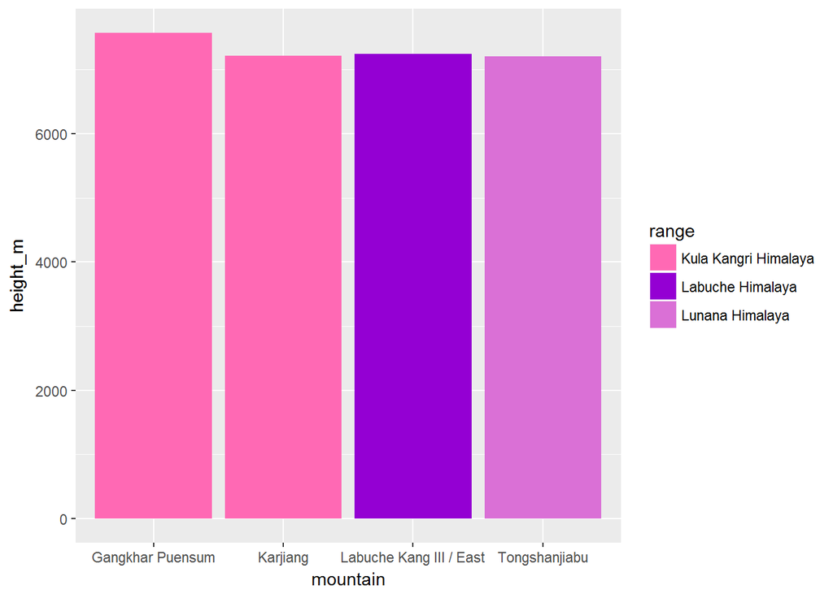

```r
mount %>% filter(first_ascent =="unclimbed")%>% ggplot(aes(x=mountain,y=height_m,fill=range))+geom_bar(stat="identity")+scale_fill_manual(values=c("hotpink","darkviolet","orchid"))
```

Reasons why these mountains are unclimed

[figure not shown]

```r
t<-mount%>%select(mountain,range,parent_mountain,height_m,prominence_m,first_ascent)%>% filter(first_ascent =="unclimbed")
grid.table(t)
```

**1)Gangkhar Puensam- 7570 meters** It lies on the border of Bhutan and Tibet,There were four unsuccessful summit attempts before the mountain was closed to climbing in 1994. Out of respect for local spiritual beliefs, mountaineering is forbidden in Bhutan from 2004.  
**2)Labuche Kang III / East 7250 meters**  
The main summit of this Tibetan peak, at 7367 meters, was climbed by a Japanese team in 1987 and it remains the only successful summit.  
**3)Karjiang 7221 meters**  
Terrain near Karjiang’s summit is extremely technical, and there is a high risk of avalanches  
**4)Tongshanjiabu 7207 meters**  
It sits in the disputed border territory between Bhutan and China. Tongshanjiabu has never been officially climbed.

## First Ascent

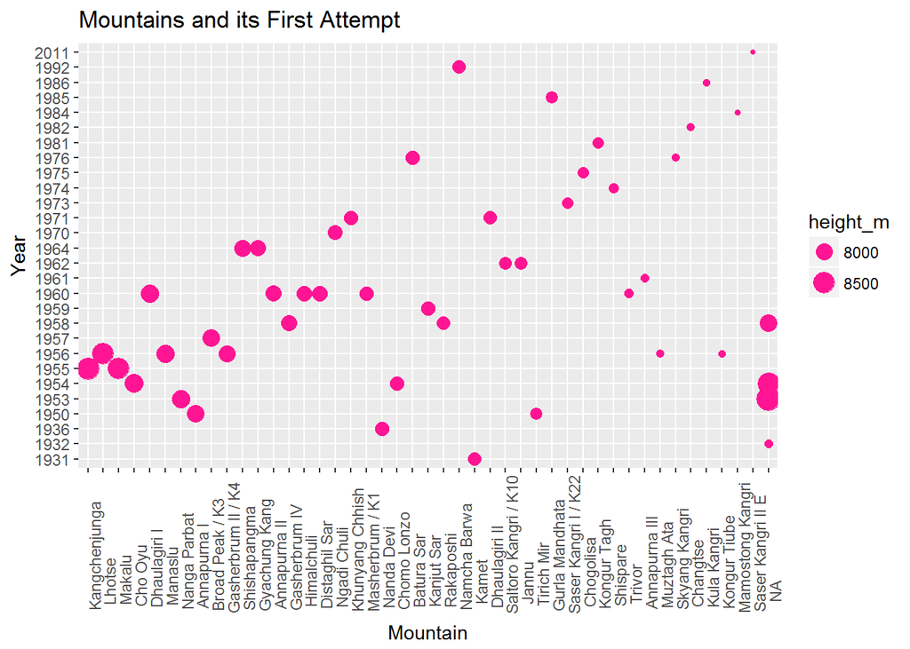

```r
mount%>% filter(first_ascent != "unclimbed" & rank<50)%>%ggplot(aes(factor(substr(mountain,1,20),levels=mountain),first_ascent,size=height_m))+geom_point(color="deeppink")+theme(axis.text.x = element_text(angle=90,hjust=0.1))+labs(title="Mountains and its First Attempt",x="Mountain",y="Year")
```

Number of successful Attempts

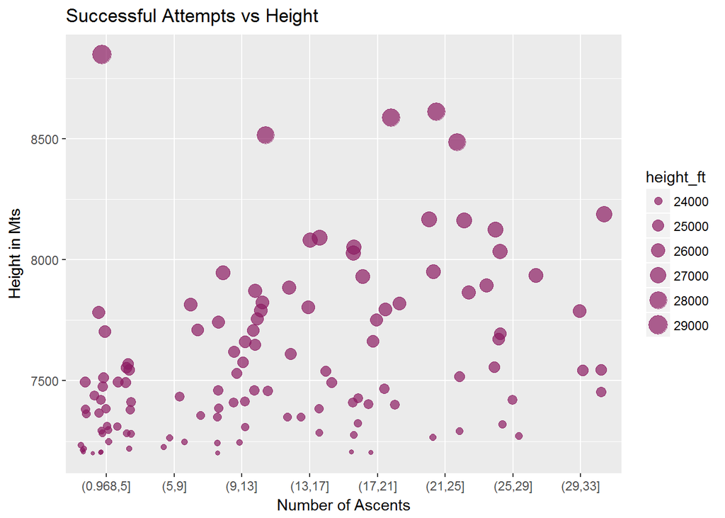

```r
mount$ascent_bef_2004<-as.numeric(as.factor(mount$ascent_bef_2004))
ggplot(mount,aes(x=cut(ascent_bef_2004,8),y=height_m,size=height_ft))+
  geom_jitter(color="maroon4",alpha=0.7)+labs(title="Successful Attempts vs Height",x="Number of Ascents",y="Height in Mts")
```

Scuccessful Attempts in each Mountain Range

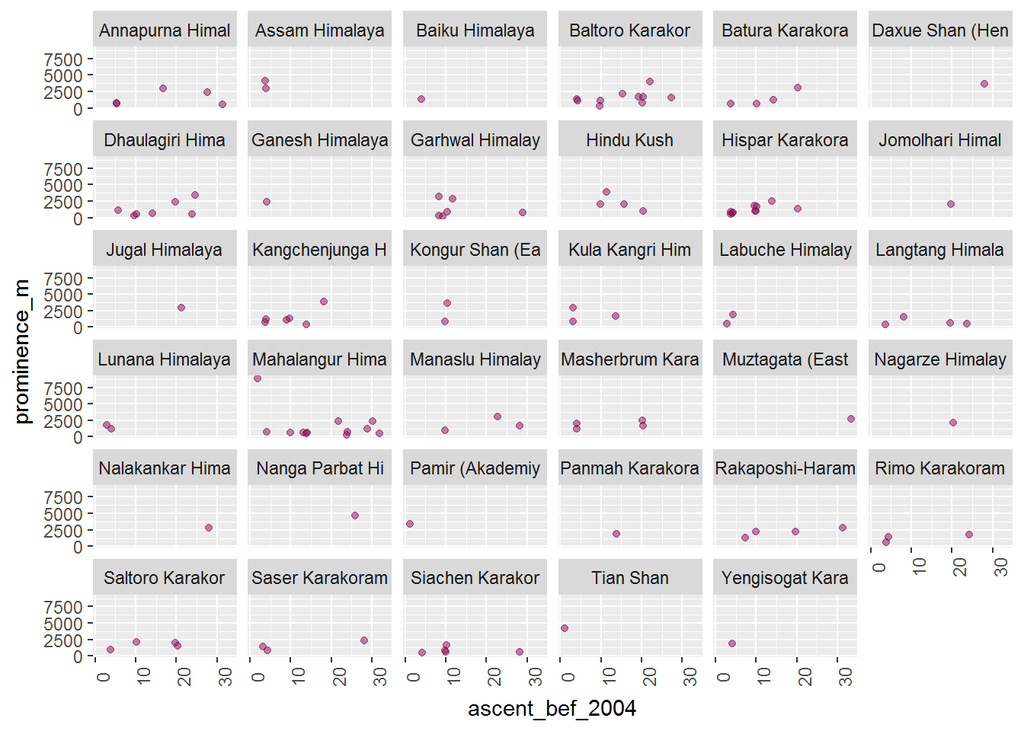

```r
  ggplot(mount,aes(ascent_bef_2004,prominence_m))+geom_jitter(color="deeppink4",alpha=0.5)+facet_wrap(~substr(range,1,15))+theme(axis.text.x = element_text(angle=90))
```

##Success Rate  
create 3 more varaibles Total attempts & success rate and difficult_level.

[figure not shown]

```r
mount$ascent_bef_2004<-as.numeric(as.factor(mount$ascent_bef_2004))

mount$ascent_bef_2004[is.na(mount$ascent_bef_2004)]<-0
srate<-mount%>% select(mountain,height_m,rank,ascent_bef_2004,failed_bef_2004)%>%mutate(total_attempts=ascent_bef_2004+failed_bef_2004,success_rate=round((ascent_bef_2004/total_attempts*100)))%>% arrange(desc(success_rate))
srate$difficult_level[srate$success_rate >80]<-"Easy"
srate$difficult_level[srate$success_rate<80 & srate$success_rate>=50]<-"Normal"
srate$difficult_level[srate$success_rate<50 & srate$success_rate>=25]<-"Hard"
srate$difficult_level[srate$success_rate<25]<-"Challenging"
grid.table(srate%>%select(mountain,height_m,rank,success_rate,difficult_level))
```